# Hw 6

Sona Thomas github: sthomas20

4/16/2020

## Top dogs

In this homework, you will try to reproduce the fantastic infographic for [top dogs](https://informationisbeautiful.net/visualizations/best-in-show-whats-the-top-data-dog/), originally produced by David McCandless. The raw data can be found [here](https://docs.google.com/spreadsheets/d/1l_HfF5EaN-QgnLc2UYdCc7L2CVrk0p3VdGB1godOyhk/edit#gid=10). You can download this file by File – Download As – Microsoft Excel (.xlsx).

**Submission instructions**: Create a folder named `ds202_hw6`, and name the RMarkDown file including your solutions `hw6.Rmd` under this folder. For the submission, create a GitHub repository named `ds202_hw6` under your GitHub account, and push both `hw6.Rmd` and the knitted `hw6.html` before the deadline. I will assume you use the same GitHub username as for your HW5 submission. The latest version of your homework appearing on GitHub before the deadline is graded. *It is crucial to follow the exact folder structure and file names*, so that your homework can be reproduced and graded by an automated script. This homework is **due on April 22** before class.

1. Import the data and clean appropriately. To read in the data, you can use `readxl::read_xlsx('fileNameHere', sheet='sheetNameHere')`. Required data are in the sheets `Best in show` and `Best in show full sheet`. Take extra care on the column names and the first few rows of the data frame after read in.

```r
#loading in the data from the environment and "import dataset" in RStudio
KIB_Best_in_Show_public_full <- read_excel("KIB_Best_in_Show.xlsx", sheet = "Best in show full sheet", range = "A3:BS178")
```

```
## * `` -> ...2
## * `` -> ...4
## * `` -> ...10
## * … and 5 more problems
```

```r
full <- KIB_Best_in_Show_public_full

KIB_Best_in_Show_public_ <- read_excel("KIB_Best_in_Show.xlsx", sheet = "Best in show", range = "A6:BS181")
```

```
## * `` -> ...2
## * `` -> ...4
## * `` -> ...6
## * `` -> ...8
## * `` -> ...13
## * … and 23 more problems
```

```r
best <- KIB_Best_in_Show_public_

#removing first row of each dataset
clean_full <- full %>%
  filter(`Sources - see bottom right` != 'Dog breed')

clean_best <- best %>%
  filter(category != 'American Kennel Club group')



#choosing columns needed from clean_best
NEWclean_best<- clean_best %>%
  select(`Dog breed`, category, `size category`, `popularity ranking (1-173, 1 = most popular)`, `intelligence category`)

#renaming columns
NEWclean_best <- NEWclean_best %>%
  rename(Dog_breed = `Dog breed`, size_category = `size category`, Popularity = `popularity ranking (1-173, 1 = most popular)`, intelligence_category = `intelligence category`)

#relabeling intelligence category
NEWclean_best$intelligence_category[NEWclean_best$intelligence_category == 'Above average'| NEWclean_best$intelligence_category == 'Brightest' | NEWclean_best$intelligence_category == 'Excellent'] <- 'Clever'

NEWclean_best$intelligence_category[NEWclean_best$intelligence_category == 'no data'| NEWclean_best$intelligence_category == 'Lowest' | NEWclean_best$intelligence_category == 'Fair'| NEWclean_best$intelligence_category == 'Average'] <- 'Dumb'



#choosing columns needed from clean_full
NEWclean_full <- clean_full %>%
  select(`datadog score`, `Sources - see bottom right`)

#renaming columns
NEWclean_full <- NEWclean_full %>%
  rename(Dog_score = `datadog score`, Dog_breed = `Sources - see bottom right`)


#Joining data frames together
dog <- merge(NEWclean_best, NEWclean_full, by=c('Dog_breed'))


#converting types
dog$Popularity <- as.integer(dog$Popularity)
dog$category <- as.factor(dog$category)
dog$size_category <- as.factor(dog$size_category)
```

2. Create a graphics similar to the [top dogs](https://informationisbeautiful.net/visualizations/best-in-show-whats-the-top-data-dog/) figure. Your figure needs to display the following information with appropriate plotting elements:
- breed of dog
- type of dog (work, toy, etc.)
- size of dog
- data score
- popularity
- intelligence of the dog
- appropriate legends & explanation

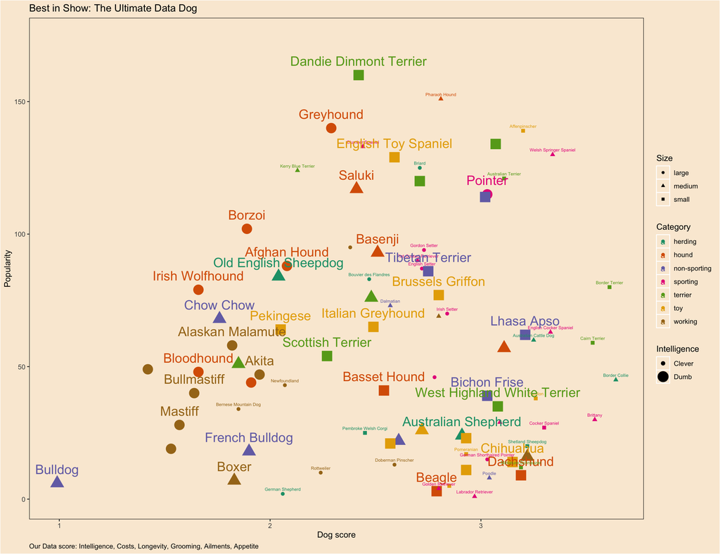

```r
ggplot(dog, aes(x=Dog_score, y=Popularity, color=category, shape = size_category, size = intelligence_category)) + geom_point() + geom_text(aes(label = Dog_breed), check_overlap = TRUE, vjust=-1) + theme(panel.background = element_rect(fill = 'antiquewhite', colour = 'black'), plot.background = element_rect(fill = "antiquewhite"), legend.background = element_rect(fill = "antiquewhite"), legend.key = element_rect(fill = 'antiquewhite'), plot.caption = element_text(hjust = 0)) + scale_color_brewer(palette="Dark2") + theme(panel.grid.major = element_blank(), panel.grid.minor = element_blank()) + labs(caption = "Our Data score: Intelligence, Costs, Longevity, Grooming, Ailments, Appetite" , color = "Category", shape='Size', size= 'Intelligence') + xlab("Dog score") + ggtitle('Best in Show: The Ultimate Data Dog')
```

- After importing and cleaning the data I have produced the above plot as closely as I could to the The Ultimate Data Dog infographic. When looking at the plot you can see that I replicated the infographic by putting the composite score on the x-axis, Popularity on the y-axis, used the shape argument to describe the size of the dog, used color argument to describe the type of dog it is “herding, toy, working, etc.”, used geom_text to label the each point as the the type of dog breed, and used the size argument to display the intelligence of the dog. Orginally intelligence was listed as more than two categories such as “excellent, fair, average, lowest, brightest, etc” but I used a condition based on my judgement to determine which dogs can be categorized as clever and dumb that way it is easier to visualize the intelligence category. You can see how I did to in the code above the plot.

Hints and Notes:

- The breed of dog can be displayed without the silhouttes (text only is fine)
- Avoid (too much) overlaps!
- Choose a good color scheme.
- Your submission is supposed to be fully reproducible, i.e. the TA and I will ‘knit’ your submission in RStudio.